## **MECE**

| **Task Category** | **Tasks** | **Assigned To** |
| --- | --- | --- |
| **Data Preprocessing** | Cleaning text, removing noise, handling emojis/slangs | **TIRTH** |
| **Word2Vec Embeddings** | Training Word2Vec (Skipgram), extracting embeddings | **TIRTH** |
| **Building Initial Model** | Defining Transformer architecture (nhead=4, FF=512) | **VANDIT** |
| **Training Initial Model** | Running training loop, tracking loss & accuracy | **VANDIT** |
| **Evaluating Initial Model** | Test accuracy, classification report, confusion matrix | **VANDIT** |
| **AUC-ROC Analysis (Initial Model)** | Computing AUC scores, plotting ROC curves | **VANDIT** |
| **Hyperparameter Tuning (Model 1)** | Increasing layers, tuning dropout, weight decay | **Tirth** |
| **Training Tuned Model 1** | Running training with new hyperparameters | **Tirth** |
| **Evaluating Tuned Model 1** | Test accuracy, classification report, confusion matrix | **TIRTH** |
| **AUC-ROC Analysis (Tuned Model 1)** | Computing AUC scores, plotting ROC curves | **TIRTH** |
| **Hyperparameter Tuning (Model 2)** | Advanced tuning (gradient accumulation, cosine LR) | **VANDIT** |
| **Training Tuned Model 2** | Running training with new regularization settings | **VANDIT** |
| **Evaluating Tuned Model 2** | Test accuracy, classification report, confusion matrix | **TIRTH** |
| **AUC-ROC Analysis (Tuned Model 2)** | Computing AUC scores, plotting ROC curves | **TIRTH** |
| **Final Model Comparison** | Creating performance table, summarizing best model | **VANDIT** |

[output not shown]

# Possible Model Improvements

- **Increase Embedding Size (128 → 300)** → Better semantic understanding (**+0.5% to +1% accuracy**).
- **More Transformer Layers (6 → 12), More Heads (8 → 16)** → Improves context learning (**+1% to +2% accuracy**).
- **Use Pretrained Embeddings (GloVe, FastText)** → Faster convergence, better generalization (**+1% to +3% AUC**).
- **Better LR Scheduling (One-Cycle LR instead of Cosine)** → Faster, more stable training (**-5% to -10% training time**).
- **Regularization Tuning (Dropout 0.2 → Dynamic 0.1-0.4)** → Reduces overfitting (**+0.5% to +1.2% macro AUC**).
- **Larger Batch with Mixed Precision (64 → 128 FP16)** → **2x faster training, no accuracy loss**.

Prompts:

```
1. Train a non-causal Transformer model for text classification using Word2Vec embeddings (Skipgram) and position embeddings. The Transformer should have multi-head attention, a feedforward network, and dropout for regularization. Train it using an appropriate loss function (CrossEntropy) and optimizer (Adam). Finally, evaluate the model using accuracy, AUC-ROC, and confusion matrix.

2. Improve the Transformer model by tuning hyperparameters. Experiment with different values for the number of attention heads, feedforward network size, dropout, weight decay, and learning rate. Train the tuned model and compare its performance with the initial model using accuracy, F1-score, and AUC-ROC

3. Generate a structured performance comparison of the initial Transformer model and the tuned models. Include key metrics like test accuracy, macro AUC, weighted AUC, F1-scores, and confusion matrices. Provide insights on which model performs best and suggest further improvements.
```

```python
import torch
import torch.nn as nn
import torch.optim as optim
from torch.utils.data import Dataset, DataLoader
from sklearn.model_selection import train_test_split
from sklearn.utils.class_weight import compute_class_weight
import numpy as np
import pandas as pd
import ast
from torch.optim.lr_scheduler import CosineAnnealingLR
from tqdm import tqdm

# Check GPU availability
device = torch.device("cuda" if torch.cuda.is_available() else "cpu")
print(f"✅ Using device: {device}")
```

```
✅ Using device: cuda
```

```python
df = pd.read_csv("cleaned_sentiment_data.csv")

# Convert 'text_seq' from string format list format
df["text_seq"] = df["text_seq"].apply(lambda x: ast.literal_eval(x) if isinstance(x, str) else x)

# Ensure all rows contain lists
df = df[df["text_seq"].apply(lambda x: isinstance(x, list))]

# Convert sentiment labels to integer format
df["Sentiment"] = df["Sentiment"].astype(int)
labels = df["Sentiment"].values  # Ensure integer format

print("✅ Dataset loaded successfully.")
```

```
✅ Dataset loaded successfully.
```

Word2vec embedings

```python
from gensim.models import Word2Vec
import torch

# Convert text to string ,fill NaN values
df["cleaned_text"] = df["cleaned_text"].astype(str).fillna("")

# Tokenize the cleaned text into lists of words
sentences = [text.split() for text in df["cleaned_text"]]

# Check if CUDA (GPU) is available
device = torch.device("cuda" if torch.cuda.is_available() else "cpu")
print(f"✅ Using device: {device}")

# Train Skip-gram Word2Vec model
w2v_model = Word2Vec(
    sentences,
    vector_size=100,
    window=5,  # Context window size
    min_count=2,  # Ignore words with less than 2 occurrences
    workers=4 if device.type == "cuda" else None,  # Use limited CPU threads if running on GPU
    sg=1  # Skip-gram model
)

# Save the trained Word2Vec model
w2v_model.save("word2vec_skipgram.bin")
print("✅ Skip-gram Word2Vec model training complete. Model saved as 'word2vec_skipgram.bin'.")
```

```
✅ Using device: cuda
✅ Skip-gram Word2Vec model training complete. Model saved as 'word2vec_skipgram.bin'.
```

Positional embedings

```python
import numpy as np

# Function to generate sinusoidal position embeddings
def get_sinusoidal_embeddings(max_len, embedding_dim):
    position = np.arange(max_len)[:, np.newaxis]  # Positions (0 to max_len-1)
    div_term = np.exp(np.arange(0, embedding_dim, 2) * -(np.log(10000.0) / embedding_dim))

    # Compute sin for even indices, cos for odd indices
    pos_embedding = np.zeros((max_len, embedding_dim))
    pos_embedding[:, 0::2] = np.sin(position * div_term)
    pos_embedding[:, 1::2] = np.cos(position * div_term)

    return pos_embedding

# Set parameters
max_seq_length = 100  # Maximum sentence length
embedding_dim = 100  # Should match Word2Vec vector size

# Generate position embeddings
position_embeddings = get_sinusoidal_embeddings(max_seq_length, embedding_dim)

# Save embeddings
np.save("position_embeddings.npy", position_embeddings)

print("✅ Position embeddings generated and saved as 'position_embeddings.npy'.")
```

```
✅ Position embeddings generated and saved as 'position_embeddings.npy'.
```

load pretrained wor2vec and position embedings

```python
from gensim.models import Word2Vec
import numpy as np

w2v_model = Word2Vec.load("word2vec_skipgram.bin")
print("✅ Loaded pre-trained Word2Vec model.")

position_embeddings = np.load("position_embeddings.npy")
print("✅ Loaded pre-generated positional embeddings.")

# Ensure correct shape
print(f"Word2Vec embedding shape: {w2v_model.wv.vectors.shape}")
print(f"Positional embedding shape: {position_embeddings.shape}")
```

```
✅ Loaded pre-trained Word2Vec model.
✅ Loaded pre-generated positional embeddings.
Word2Vec embedding shape: (110897, 100)
Positional embedding shape: (100, 100)
```

train validation test split

```python
train_texts, temp_texts, train_labels, temp_labels = train_test_split(
    df["text_seq"].tolist(), df["Sentiment"].values, test_size=0.3, random_state=42
)
val_texts, test_texts, val_labels, test_labels = train_test_split(
    temp_texts, temp_labels, test_size=0.5, random_state=42
)

print(f"✅ Dataset split: {len(train_texts)} train, {len(val_texts)} val, {len(test_texts)} test")
```

```
✅ Dataset split: 315932 train, 67700 val, 67700 test
```

pytorch dataset and dataloader

```python
import torch
from torch.utils.data import Dataset, DataLoader

# Define PyTorch Dataset
class TextDataset(Dataset):
    def __init__(self, texts, labels):
        self.texts = torch.tensor(texts, dtype=torch.long)
        self.labels = torch.tensor(labels, dtype=torch.long)

    def __len__(self):
        return len(self.texts)

    def __getitem__(self, idx):
        return self.texts[idx], self.labels[idx]

# Create Dataset
batch_size = 64
train_dataset = TextDataset(train_texts, train_labels)
val_dataset = TextDataset(val_texts, val_labels)
test_dataset = TextDataset(test_texts, test_labels)

# Create DataLoaders
train_loader = DataLoader(train_dataset, batch_size=batch_size, shuffle=True)
val_loader = DataLoader(val_dataset, batch_size=batch_size, shuffle=False)
test_loader = DataLoader(test_dataset, batch_size=batch_size, shuffle=False)

print("✅ PyTorch DataLoader created successfully.")
```

```
✅ PyTorch DataLoader created successfully.
```

compute class weights for imbalanced class

```python
from sklearn.utils.class_weight import compute_class_weight
import numpy as np

# Compute class weights for imbalanced data
class_weights = compute_class_weight("balanced", classes=np.array([0, 1, 2, 3, 4]), y=df["Sentiment"].values)
class_weights = torch.tensor(class_weights, dtype=torch.float).to(device)

print(f"✅ Computed class weights: {class_weights}")
```

```
✅ Computed class weights: tensor([0.3862, 1.4103, 1.1720, 2.6505, 2.1211], device='cuda:0')
```

cvonfig for model 1 nhead=4 feedforward= 512 loss function = cross entropy optimizer= adam epoch = 10 weight decay=0.01 learning rate=3e-4

define transformer model (initial)

```python
import torch.nn as nn

class InitialTransformer(nn.Module):
    def __init__(self, vocab_size, embedding_dim, max_seq_length, num_classes=5):
        super(InitialTransformer, self).__init__()

        # Word Embedding Layer
        self.word_embedding = nn.Embedding(vocab_size, embedding_dim)

        # Transformer Encoder Layer (Simpler Version)
        self.transformer_layer = nn.TransformerEncoderLayer(
            d_model=embedding_dim,
            nhead=4,  # Fewer attention heads (simpler)
            dim_feedforward=512,  # Smaller feedforward network
            dropout=0.1,  # Lower dropout
            batch_first=True
        )

        # Single Transformer Encoder Layer
        self.transformer_encoder = nn.TransformerEncoder(
            self.transformer_layer, num_layers=3  # Fewer layers
        )

        # Output layer (Classification)
        self.fc = nn.Linear(embedding_dim, num_classes)

    def forward(self, x):
        # Word embeddings
        word_emb = self.word_embedding(x)

        # Transformer processing
        x = self.transformer_encoder(word_emb)

        # Classification layer (using first token representation)
        x = self.fc(x[:, 0, :])

        return x

# Initialize Initial Model
embedding_dim = 100  # Match Word2Vec vector size
vocab_size = 200000  # Adjust based on dataset
model = InitialTransformer(vocab_size, embedding_dim, max_seq_length=100).to(device)

print("✅ Initial Transformer model initialized successfully.")
```

```
✅ Initial Transformer model initialized successfully.
```

setup training components with loss function, optimizer and learning rate schedulaer

```python
import torch.optim as optim
from torch.optim.lr_scheduler import CosineAnnealingLR

# Define Loss Function with Class Weights
criterion = nn.CrossEntropyLoss(weight=class_weights)

# Define Optimizer (AdamW works well with Transformers)
optimizer = optim.AdamW(initial_model.parameters(), lr=3e-4, weight_decay=0.01)

# Define Learning Rate Scheduler (Reduces LR over time)
scheduler = CosineAnnealingLR(optimizer, T_max=10, eta_min=1e-6)

print("✅ Loss function, optimizer, and scheduler initialized.")
```

```
✅ Loss function, optimizer, and scheduler initialized.
```

train loop

```python
num_epochs = 10  # Number of epochs for training
best_val_loss = float('inf')  # Track the best validation loss
patience = 3  # Early stopping patience
patience_counter = 0

for epoch in range(num_epochs):
    # Training phase
    initial_model.train()
    total_train_loss = 0
    train_correct = 0
    train_total = 0

    for batch_idx, (texts, labels) in enumerate(tqdm(train_loader, desc=f'Epoch {epoch+1}/{num_epochs}')):
        texts, labels = texts.to(device), labels.to(device)

        optimizer.zero_grad()
        outputs = initial_model(texts)
        loss = criterion(outputs, labels)
        loss.backward()

        # Gradient clipping to prevent exploding gradients
        torch.nn.utils.clip_grad_norm_(initial_model.parameters(), max_norm=1.0)

        optimizer.step()

        total_train_loss += loss.item()
        _, predicted = torch.max(outputs.data, 1)
        train_total += labels.size(0)
        train_correct += (predicted == labels).sum().item()

    avg_train_loss = total_train_loss / len(train_loader)
    train_accuracy = 100 * train_correct / train_total

    # Validation phase
    initial_model.eval()
    total_val_loss = 0
    val_correct = 0
    val_total = 0

    with torch.no_grad():
        for texts, labels in val_loader:
            texts, labels = texts.to(device), labels.to(device)
            outputs = initial_model(texts)
            loss = criterion(outputs, labels)

            total_val_loss += loss.item()
            _, predicted = torch.max(outputs.data, 1)
            val_total += labels.size(0)
            val_correct += (predicted == labels).sum().item()

    avg_val_loss = total_val_loss / len(val_loader)
    val_accuracy = 100 * val_correct / val_total

    print(f"\n✅ Epoch [{epoch+1}/{num_epochs}]")
    print(f"Train Loss: {avg_train_loss:.4f}, Train Accuracy: {train_accuracy:.2f}%")
    print(f"Val Loss: {avg_val_loss:.4f}, Val Accuracy: {val_accuracy:.2f}%")

    # Learning rate scheduling
    scheduler.step()

    # Early stopping check
    if avg_val_loss < best_val_loss:
        best_val_loss = avg_val_loss
        patience_counter = 0
        torch.save(initial_model.state_dict(), "initial_transformer_model.pth")  # Save best model
    else:
        patience_counter += 1
        if patience_counter >= patience:
            print(f"🚨 Early stopping triggered after {epoch+1} epochs")
            break

print("✅ Initial Transformer Model Training Complete!")
```

```
✅ Epoch [1/10]
Train Loss: 1.2588, Train Accuracy: 55.60%
Val Loss: 1.1172, Val Accuracy: 64.96%
```

```
✅ Epoch [2/10]
Train Loss: 1.0280, Train Accuracy: 66.36%
Val Loss: 1.0209, Val Accuracy: 67.70%
```

```
✅ Epoch [3/10]
Train Loss: 0.9204, Train Accuracy: 70.76%
Val Loss: 0.9892, Val Accuracy: 70.39%
```

```
✅ Epoch [4/10]
Train Loss: 0.8536, Train Accuracy: 73.33%
Val Loss: 0.9230, Val Accuracy: 71.97%
```

```
✅ Epoch [5/10]
Train Loss: 0.8008, Train Accuracy: 75.06%
Val Loss: 0.9180, Val Accuracy: 72.24%
```

```
✅ Epoch [6/10]
Train Loss: 0.7579, Train Accuracy: 76.42%
Val Loss: 0.9289, Val Accuracy: 72.93%
```

```
✅ Epoch [7/10]
Train Loss: 0.7237, Train Accuracy: 77.63%
Val Loss: 0.8969, Val Accuracy: 74.01%
```

```
✅ Epoch [8/10]
Train Loss: 0.6957, Train Accuracy: 78.51%
Val Loss: 0.9265, Val Accuracy: 73.21%
```

```
✅ Epoch [9/10]
Train Loss: 0.6750, Train Accuracy: 79.10%
Val Loss: 0.9055, Val Accuracy: 73.99%
```

```
✅ Epoch [10/10]
Train Loss: 0.6617, Train Accuracy: 79.56%
Val Loss: 0.9108, Val Accuracy: 73.97%
🚨 Early stopping triggered after 10 epochs
✅ Initial Transformer Model Training Complete!
```

Training time initial model 142 min

EVA;UATE INITIAL MODEL

```python
from sklearn.metrics import accuracy_score, classification_report

# Load the best model saved during training
initial_model.load_state_dict(torch.load("initial_transformer_model.pth"))
initial_model.to(device)
initial_model.eval()

test_correct = 0
test_total = 0
all_preds = []
all_labels = []

# No gradients needed during evaluation
with torch.no_grad():
    for texts, labels in test_loader:
        texts, labels = texts.to(device), labels.to(device)
        outputs = initial_model(texts)
        preds = torch.argmax(outputs, dim=1)  # Get predicted class

        all_preds.extend(preds.cpu().numpy())  # Store predictions
        all_labels.extend(labels.cpu().numpy())  # Store true labels

# Calculate accuracy
test_accuracy = accuracy_score(all_labels, all_preds)
print(f"\n✅ Initial Model Test Accuracy: {test_accuracy:.4f}")

# Generate classification report
print("\n🔹 Classification Report (Initial Model):")
print(classification_report(all_labels, all_preds))
```

```
✅ Initial Model Test Accuracy: 0.7393

🔹 Classification Report (Initial Model):
              precision    recall  f1-score   support

           0       0.91      0.85      0.88     35037
           1       0.54      0.63      0.58      9674
           2       0.79      0.61      0.69     11545
           3       0.43      0.49      0.46      5142
           4       0.54      0.76      0.63      6302

    accuracy                           0.74     67700
   macro avg       0.64      0.67      0.65     67700
weighted avg       0.76      0.74      0.75     67700
```

AUC ROC

```python
from sklearn.metrics import roc_auc_score
import torch.nn.functional as F

# Ensure model is in evaluation mode
initial_model.eval()

all_probs = []  # Store predicted probabilities
all_labels = []  # Store true labels

# No gradient needed for evaluation
with torch.no_grad():
    for texts, labels in test_loader:
        texts, labels = texts.to(device), labels.to(device)
        outputs = initial_model(texts)
        probs = F.softmax(outputs, dim=1)  # Convert logits to probabilities

        all_probs.extend(probs.cpu().numpy())  # Convert to NumPy array
        all_labels.extend(labels.cpu().numpy())

# Convert lists to NumPy arrays
all_probs = np.array(all_probs)
all_labels = np.array(all_labels)

# Compute AUC for each class (One-vs-Rest)
auc_scores = {}
for i in range(5):  # 5 sentiment classes (0, 1, 2, 3, 4)
    binary_labels = (all_labels == i).astype(int)  # Convert to binary for AUC calculation
    auc_scores[f"Class {i}"] = roc_auc_score(binary_labels, all_probs[:, i])

# Print AUC Scores
print("\n✅ AUC Scores for Initial Transformer Model:")
for class_name, auc in auc_scores.items():
    print(f"{class_name}: {auc:.4f}")

# Compute Macro & Weighted AUC
macro_auc = roc_auc_score(all_labels, all_probs, multi_class="ovr", average="macro")
weighted_auc = roc_auc_score(all_labels, all_probs, multi_class="ovr", average="weighted")

print(f"\n🔹 Macro AUC: {macro_auc:.4f}")
print(f"🔹 Weighted AUC: {weighted_auc:.4f}")
```

```
✅ AUC Scores for Initial Transformer Model:
Class 0: 0.9451
Class 1: 0.8789
Class 2: 0.9031
Class 3: 0.8880
Class 4: 0.9424

🔹 Macro AUC: 0.9115
🔹 Weighted AUC: 0.9239
```

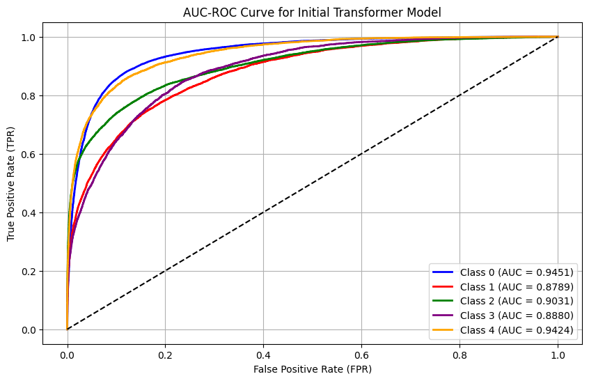

```python
import matplotlib.pyplot as plt
from sklearn.metrics import roc_curve, auc

# Set up the plot
plt.figure(figsize=(10, 6))

# Define colors for each class
colors = ['blue', 'red', 'green', 'purple', 'orange']
class_labels = ["Class 0", "Class 1", "Class 2", "Class 3", "Class 4"]

# Plot ROC curve for each class
for i, color in enumerate(colors):
    binary_labels = (all_labels == i).astype(int)  # Convert to binary for AUC calculation
    fpr, tpr, _ = roc_curve(binary_labels, all_probs[:, i])  # Compute FPR, TPR
    roc_auc = auc(fpr, tpr)  # Compute AUC
    plt.plot(fpr, tpr, color=color, lw=2, label=f'{class_labels[i]} (AUC = {roc_auc:.4f})')

# Plot diagonal (random classifier)
plt.plot([0, 1], [0, 1], color='black', linestyle='--', lw=1.5)

# Labels and title
plt.xlabel("False Positive Rate (FPR)")
plt.ylabel("True Positive Rate (TPR)")
plt.title("AUC-ROC Curve for Initial Transformer Model")
plt.legend(loc="lower right")
plt.grid(True)

# Show the plot
plt.show()
```

TUNING 1

config for model 2 nhead=8 feedforward=1024 dropout=0.2 weight decay=0.005 learning rate = 2e-4

CHANGES NO.OF LAYER PREV3 NOW6, ATTENTION HEADS PREV 4 NOW 8, FEEDFORWARD PREV 515 NOW 1024, DROPOUT PREV 0.1 NOW 0.2, WEIGHT DECAY PREV 0.01 NOW 0.005 , LEARNING RATE PREV 3e-4 NOW 2e-4

```python
import torch.nn as nn

class TunedTransformer(nn.Module):
    def __init__(self, vocab_size, embedding_dim, max_seq_length, num_classes=5):
        super(TunedTransformer, self).__init__()

        # Word Embedding Layer
        self.word_embedding = nn.Embedding(vocab_size, embedding_dim)
        self.embedding_norm = nn.LayerNorm(embedding_dim)

        # Transformer Encoder Layer (Tuned)
        num_heads = 8
        self.transformer_layer = nn.TransformerEncoderLayer(
            d_model=embedding_dim,  # Must be divisible by num_heads
            nhead=num_heads,
            dim_feedforward=1024,  # Increased FFN size
            dropout=0.2,  # Increased dropout
            batch_first=True,
            norm_first=True  # Pre-Normalization for stability
        )

        # More Transformer Layers (Tuned)
        self.transformer_encoder = nn.TransformerEncoder(
            self.transformer_layer, num_layers=6  # Increased from 3 to 6 layers
        )

        # Output layer
        self.dropout = nn.Dropout(0.2)
        self.fc = nn.Linear(embedding_dim, num_classes)

    def forward(self, x):
        word_emb = self.word_embedding(x)
        word_emb = self.embedding_norm(word_emb)
        x = self.transformer_encoder(word_emb)
        x = self.dropout(x[:, 0, :])
        x = self.fc(x)
        return x

embedding_dim = 128
vocab_size = 200000
tuned_model = TunedTransformer(vocab_size, embedding_dim, max_seq_length=100).to(device)

print("✅ Tuned Transformer Model Initialized Successfully.")
```

```
✅ Tuned Transformer Model Initialized Successfully.
```

setup loss function optimizer learng rate scheduler

```python
import torch.optim as optim
from torch.optim.lr_scheduler import CosineAnnealingLR

# Define Loss Function with Class Weights
criterion = nn.CrossEntropyLoss(weight=class_weights)

# Define Optimizer (Lower learning rate for stability)
optimizer = optim.AdamW(tuned_model.parameters(), lr=2e-4, weight_decay=0.005)  # Reduced weight decay

# Define Learning Rate Scheduler (Smoothly reduces LR over epochs)
scheduler = CosineAnnealingLR(optimizer, T_max=10, eta_min=1e-6)

print("✅ Loss function, optimizer, and scheduler initialized for Tuned Model.")
```

```
✅ Loss function, optimizer, and scheduler initialized for Tuned Model.
```

TRAIN TUNED MODEL

```python
num_epochs = 10  # Training for 10 epochs
best_val_loss = float('inf')  # Track the best validation loss
patience = 3  # Early stopping if no improvement for 3 epochs
patience_counter = 0

for epoch in range(num_epochs):
    # Training Phase
    tuned_model.train()
    total_train_loss = 0
    train_correct = 0
    train_total = 0

    for batch_idx, (texts, labels) in enumerate(tqdm(train_loader, desc=f'Epoch {epoch+1}/{num_epochs}')):
        texts, labels = texts.to(device), labels.to(device)

        optimizer.zero_grad()
        outputs = tuned_model(texts)
        loss = criterion(outputs, labels)
        loss.backward()

        # Gradient clipping to prevent exploding gradients
        torch.nn.utils.clip_grad_norm_(tuned_model.parameters(), max_norm=1.0)

        optimizer.step()

        total_train_loss += loss.item()
        _, predicted = torch.max(outputs.data, 1)
        train_total += labels.size(0)
        train_correct += (predicted == labels).sum().item()

    avg_train_loss = total_train_loss / len(train_loader)
    train_accuracy = 100 * train_correct / train_total

    # Validation Phase
    tuned_model.eval()
    total_val_loss = 0
    val_correct = 0
    val_total = 0

    with torch.no_grad():
        for texts, labels in val_loader:
            texts, labels = texts.to(device), labels.to(device)
            outputs = tuned_model(texts)
            loss = criterion(outputs, labels)

            total_val_loss += loss.item()
            _, predicted = torch.max(outputs.data, 1)
            val_total += labels.size(0)
            val_correct += (predicted == labels).sum().item()

    avg_val_loss = total_val_loss / len(val_loader)
    val_accuracy = 100 * val_correct / val_total

    print(f"\n✅ Epoch [{epoch+1}/{num_epochs}]")
    print(f"Train Loss: {avg_train_loss:.4f}, Train Accuracy: {train_accuracy:.2f}%")
    print(f"Val Loss: {avg_val_loss:.4f}, Val Accuracy: {val_accuracy:.2f}%")

    # Adjust learning rate
    scheduler.step()

    # Early Stopping Check
    if avg_val_loss < best_val_loss:
        best_val_loss = avg_val_loss
        patience_counter = 0
        torch.save(tuned_model.state_dict(), "tuned_transformer_model.pth")  # Save best model
    else:
        patience_counter += 1
        if patience_counter >= patience:
            print(f"🚨 Early stopping triggered after {epoch+1} epochs")
            break

print("✅ Tuned Transformer Model Training Complete!")
```

```
✅ Epoch [1/10]
Train Loss: 1.2492, Train Accuracy: 55.99%
Val Loss: 1.1086, Val Accuracy: 68.54%
```

```
✅ Epoch [2/10]
Train Loss: 0.9951, Train Accuracy: 67.80%
Val Loss: 0.9753, Val Accuracy: 70.73%
```

```
✅ Epoch [3/10]
Train Loss: 0.8981, Train Accuracy: 71.43%
Val Loss: 0.9412, Val Accuracy: 70.66%
```

```
✅ Epoch [4/10]
Train Loss: 0.8316, Train Accuracy: 73.76%
Val Loss: 0.9002, Val Accuracy: 70.74%
```

```
✅ Epoch [5/10]
Train Loss: 0.7766, Train Accuracy: 75.40%
Val Loss: 0.9030, Val Accuracy: 73.48%
```

```
✅ Epoch [6/10]
Train Loss: 0.7259, Train Accuracy: 76.87%
Val Loss: 0.9248, Val Accuracy: 73.13%
```

```
✅ Epoch [7/10]
Train Loss: 0.6785, Train Accuracy: 78.22%
Val Loss: 0.9332, Val Accuracy: 73.95%
🚨 Early stopping triggered after 7 epochs
✅ Tuned Transformer Model Training Complete!
```

train time tuned model 60 minutes

```python
from sklearn.metrics import accuracy_score, classification_report

# Load the best tuned model saved during training
tuned_model.load_state_dict(torch.load("tuned_transformer_model.pth"))
tuned_model.to(device)
tuned_model.eval()

test_correct = 0
test_total = 0
all_preds = []
all_labels = []

# No gradient needed for evaluation
with torch.no_grad():
    for texts, labels in test_loader:
        texts, labels = texts.to(device), labels.to(device)
        outputs = tuned_model(texts)
        preds = torch.argmax(outputs, dim=1)  # Get predicted class

        all_preds.extend(preds.cpu().numpy())  # Store predictions
        all_labels.extend(labels.cpu().numpy())  # Store true labels

# Calculate accuracy
test_accuracy = accuracy_score(all_labels, all_preds)
print(f"\n✅ Tuned Model Test Accuracy: {test_accuracy:.4f}")

# Generate classification report
print("\n🔹 Classification Report (Tuned Model):")
print(classification_report(all_labels, all_preds))
```

```
✅ Tuned Model Test Accuracy: 0.7098

🔹 Classification Report (Tuned Model):
              precision    recall  f1-score   support

           0       0.93      0.78      0.85     35037
           1       0.48      0.64      0.55      9674
           2       0.80      0.60      0.69     11545
           3       0.35      0.55      0.43      5142
           4       0.57      0.74      0.64      6302

    accuracy                           0.71     67700
   macro avg       0.62      0.66      0.63     67700
weighted avg       0.76      0.71      0.73     67700
```

AUC ROC

```python
from sklearn.metrics import roc_auc_score
import torch.nn.functional as F

# Ensure model is in evaluation mode
tuned_model.eval()

all_probs = []  # Store predicted probabilities
all_labels = []  # Store true labels

# No gradient needed for evaluation
with torch.no_grad():
    for texts, labels in test_loader:
        texts, labels = texts.to(device), labels.to(device)
        outputs = tuned_model(texts)
        probs = F.softmax(outputs, dim=1)  # Convert logits to probabilities

        all_probs.extend(probs.cpu().numpy())  # Convert to NumPy array
        all_labels.extend(labels.cpu().numpy())

# Convert lists to NumPy arrays
all_probs = np.array(all_probs)
all_labels = np.array(all_labels)

# Compute AUC for each class (One-vs-Rest)
auc_scores = {}
for i in range(5):  # 5 sentiment classes (0, 1, 2, 3, 4)
    binary_labels = (all_labels == i).astype(int)  # Convert to binary for AUC calculation
    auc_scores[f"Class {i}"] = roc_auc_score(binary_labels, all_probs[:, i])

# Print AUC Scores
print("\n✅ AUC Scores for Tuned Transformer Model:")
for class_name, auc in auc_scores.items():
    print(f"{class_name}: {auc:.4f}")

# Compute Macro & Weighted AUC
macro_auc = roc_auc_score(all_labels, all_probs, multi_class="ovr", average="macro")
weighted_auc = roc_auc_score(all_labels, all_probs, multi_class="ovr", average="weighted")

print(f"\n🔹 Macro AUC: {macro_auc:.4f}")
print(f"🔹 Weighted AUC: {weighted_auc:.4f}")
```

```
✅ AUC Scores for Tuned Transformer Model:
Class 0: 0.9428
Class 1: 0.8579
Class 2: 0.8977
Class 3: 0.8881
Class 4: 0.9435

🔹 Macro AUC: 0.9060
🔹 Weighted AUC: 0.9189
```

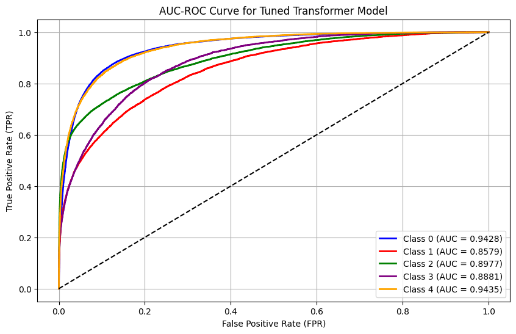

```python
import matplotlib.pyplot as plt
from sklearn.metrics import roc_curve, auc

# Set up the plot
plt.figure(figsize=(10, 6))

# Define colors for each class
colors = ['blue', 'red', 'green', 'purple', 'orange']
class_labels = ["Class 0", "Class 1", "Class 2", "Class 3", "Class 4"]

# Plot ROC curve for each class
for i, color in enumerate(colors):
    binary_labels = (all_labels == i).astype(int)  # Convert to binary for AUC calculation
    fpr, tpr, _ = roc_curve(binary_labels, all_probs[:, i])  # Compute FPR, TPR
    roc_auc = auc(fpr, tpr)  # Compute AUC
    plt.plot(fpr, tpr, color=color, lw=2, label=f'{class_labels[i]} (AUC = {roc_auc:.4f})')

# Plot diagonal (random classifier)
plt.plot([0, 1], [0, 1], color='black', linestyle='--', lw=1.5)

# Labels and title
plt.xlabel("False Positive Rate (FPR)")
plt.ylabel("True Positive Rate (TPR)")
plt.title("AUC-ROC Curve for Tuned Transformer Model")
plt.legend(loc="lower right")
plt.grid(True)

# Show the plot
plt.show()
```

TUNNING 2

config for model 3 nhead=8 feedforward=1024 dropout=0.3 embeding dim= 128

```python
import torch.nn as nn

class AdvancedTunedTransformer(nn.Module):
    def __init__(self, vocab_size, embedding_dim, max_seq_length, num_classes=5):
        super(AdvancedTunedTransformer, self).__init__()

        # Word Embedding Layer
        self.word_embedding = nn.Embedding(vocab_size, embedding_dim)
        self.embedding_norm = nn.LayerNorm(embedding_dim)

        # Transformer Encoder Layer (Tuning 2)
        num_heads = 8
        self.transformer_layer = nn.TransformerEncoderLayer(
            d_model=embedding_dim,
            nhead=num_heads,
            dim_feedforward=1024,
            dropout=0.3,  # Increased dropout
            batch_first=True,
            norm_first=True
        )

        # More Transformer Layers (Tuning 2)
        self.transformer_encoder = nn.TransformerEncoder(
            self.transformer_layer, num_layers=6
        )

        # Output layer
        self.dropout = nn.Dropout(0.3)
        self.fc = nn.Linear(embedding_dim, num_classes)

    def forward(self, x):
        word_emb = self.word_embedding(x)
        word_emb = self.embedding_norm(word_emb)
        x = self.transformer_encoder(word_emb)
        x = self.dropout(x[:, 0, :])
        x = self.fc(x)
        return x

# Initialize the Tuning 2 Model
embedding_dim = 128
vocab_size = 200000
tuning2_model = AdvancedTunedTransformer(vocab_size, embedding_dim, max_seq_length=100).to(device)

print("✅ Advanced Tuned Transformer Model Initialized Successfully.")
```

```
✅ Advanced Tuned Transformer Model Initialized Successfully.
```

```python
import torch.optim as optim
from torch.optim.lr_scheduler import CosineAnnealingLR

# Define Loss Function with Label Smoothing (Tuning 2)
criterion = nn.CrossEntropyLoss(weight=class_weights, label_smoothing=0.1)

# Define Optimizer (Tuning 2: Lower learning rate, less weight decay)
optimizer = optim.AdamW(tuning2_model.parameters(), lr=1e-4, weight_decay=0.003)

# Define Learning Rate Scheduler (Tuning 2: Longer decay cycle)
scheduler = CosineAnnealingLR(optimizer, T_max=12, eta_min=5e-6)

# Gradient Accumulation Settings
gradient_accumulation_steps = 2  # Update gradients every 2 steps

print("✅ Loss function (Label Smoothing), optimizer, and scheduler initialized for the Advanced Tuned Model.")
```

```
✅ Loss function (Label Smoothing), optimizer, and scheduler initialized for the Advanced Tuned Model.
```

```python
num_epochs = 12  # More epochs for better learning
best_val_loss = float('inf')  # Track the best validation loss
patience = 3  # Early stopping if no improvement for 3 epochs
patience_counter = 0

for epoch in range(num_epochs):
    # Training Phase
    tuning2_model.train()
    total_train_loss = 0
    train_correct = 0
    train_total = 0
    optimizer.zero_grad()  # Reset gradients

    for batch_idx, (texts, labels) in enumerate(tqdm(train_loader, desc=f'Epoch {epoch+1}/{num_epochs}')):
        texts, labels = texts.to(device), labels.to(device)

        outputs = tuning2_model(texts)
        loss = criterion(outputs, labels)
        loss.backward()

        # Gradient Accumulation (Update only every `gradient_accumulation_steps`)
        if (batch_idx + 1) % gradient_accumulation_steps == 0:
            torch.nn.utils.clip_grad_norm_(tuning2_model.parameters(), max_norm=1.0)  # Prevent exploding gradients
            optimizer.step()
            optimizer.zero_grad()

        total_train_loss += loss.item()
        _, predicted = torch.max(outputs.data, 1)
        train_total += labels.size(0)
        train_correct += (predicted == labels).sum().item()

    avg_train_loss = total_train_loss / len(train_loader)
    train_accuracy = 100 * train_correct / train_total

    # Validation Phase
    tuning2_model.eval()
    total_val_loss = 0
    val_correct = 0
    val_total = 0

    with torch.no_grad():
        for texts, labels in val_loader:
            texts, labels = texts.to(device), labels.to(device)
            outputs = tuning2_model(texts)
            loss = criterion(outputs, labels)

            total_val_loss += loss.item()
            _, predicted = torch.max(outputs.data, 1)
            val_total += labels.size(0)
            val_correct += (predicted == labels).sum().item()

    avg_val_loss = total_val_loss / len(val_loader)
    val_accuracy = 100 * val_correct / val_total

    print(f"\n✅ Epoch [{epoch+1}/{num_epochs}]")
    print(f"Train Loss: {avg_train_loss:.4f}, Train Accuracy: {train_accuracy:.2f}%")
    print(f"Val Loss: {avg_val_loss:.4f}, Val Accuracy: {val_accuracy:.2f}%")

    # Adjust learning rate
    scheduler.step()

    # Early Stopping Check
    if avg_val_loss < best_val_loss:
        best_val_loss = avg_val_loss
        patience_counter = 0
        torch.save(tuning2_model.state_dict(), "tuning2_transformer_model.pth")  # Save best model
    else:
        patience_counter += 1
        if patience_counter >= patience:
            print(f"🚨 Early stopping triggered after {epoch+1} epochs")
            break

print("✅ Advanced Tuned Transformer Model Training Complete!")
```

```
✅ Epoch [1/12]
Train Loss: 1.5964, Train Accuracy: 42.85%
Val Loss: 1.4070, Val Accuracy: 58.38%
```

```
✅ Epoch [2/12]
Train Loss: 1.3749, Train Accuracy: 60.06%
Val Loss: 1.3399, Val Accuracy: 67.35%
```

```
✅ Epoch [3/12]
Train Loss: 1.2975, Train Accuracy: 64.86%
Val Loss: 1.2763, Val Accuracy: 65.26%
```

```
✅ Epoch [4/12]
Train Loss: 1.2470, Train Accuracy: 67.71%
Val Loss: 1.2564, Val Accuracy: 69.60%
```

```
✅ Epoch [5/12]
Train Loss: 1.2115, Train Accuracy: 69.82%
Val Loss: 1.2214, Val Accuracy: 72.24%
```

```
✅ Epoch [6/12]
Train Loss: 1.1858, Train Accuracy: 71.11%
Val Loss: 1.2435, Val Accuracy: 73.16%
```

```
✅ Epoch [7/12]
Train Loss: 1.1652, Train Accuracy: 72.15%
Val Loss: 1.2101, Val Accuracy: 73.08%
```

```
✅ Epoch [8/12]
Train Loss: 1.1460, Train Accuracy: 73.22%
Val Loss: 1.2112, Val Accuracy: 73.05%
```

```
✅ Epoch [9/12]
Train Loss: 1.1324, Train Accuracy: 73.81%
Val Loss: 1.2032, Val Accuracy: 73.30%
```

```
✅ Epoch [10/12]
Train Loss: 1.1212, Train Accuracy: 74.34%
Val Loss: 1.2065, Val Accuracy: 73.95%
```

```
✅ Epoch [11/12]
Train Loss: 1.1131, Train Accuracy: 74.71%
Val Loss: 1.2107, Val Accuracy: 73.62%
```

```
✅ Epoch [12/12]
Train Loss: 1.1078, Train Accuracy: 74.96%
Val Loss: 1.2036, Val Accuracy: 73.73%
🚨 Early stopping triggered after 12 epochs
✅ Advanced Tuned Transformer Model Training Complete!
```

time to train tuned 2 model 106 min

evaluate the model

```python
from sklearn.metrics import accuracy_score, classification_report

# Load the best tuned model saved during training
tuning2_model.load_state_dict(torch.load("tuning2_transformer_model.pth"))
tuning2_model.to(device)
tuning2_model.eval()

test_correct = 0
test_total = 0
all_preds = []
all_labels = []

# No gradient needed for evaluation
with torch.no_grad():
    for texts, labels in test_loader:
        texts, labels = texts.to(device), labels.to(device)
        outputs = tuning2_model(texts)
        preds = torch.argmax(outputs, dim=1)  # Get predicted class

        all_preds.extend(preds.cpu().numpy())  # Store predictions
        all_labels.extend(labels.cpu().numpy())  # Store true labels

# Calculate accuracy
test_accuracy = accuracy_score(all_labels, all_preds)
print(f"\n✅ Advanced Tuned Model Test Accuracy: {test_accuracy:.4f}")

# Generate classification report
print("\n🔹 Classification Report (Advanced Tuned Model):")
print(classification_report(all_labels, all_preds))
```

```
✅ Advanced Tuned Model Test Accuracy: 0.7358

🔹 Classification Report (Advanced Tuned Model):
              precision    recall  f1-score   support

           0       0.89      0.86      0.87     35037
           1       0.56      0.57      0.57      9674
           2       0.79      0.60      0.68     11545
           3       0.43      0.46      0.44      5142
           4       0.51      0.77      0.62      6302

    accuracy                           0.74     67700
   macro avg       0.63      0.65      0.64     67700
weighted avg       0.75      0.74      0.74     67700
```

```python
from sklearn.metrics import roc_auc_score
import torch.nn.functional as F

# Ensure model is in evaluation mode
tuning2_model.eval()

all_probs = []  # Store predicted probabilities
all_labels = []  # Store true labels

# No gradient needed for evaluation
with torch.no_grad():
    for texts, labels in test_loader:
        texts, labels = texts.to(device), labels.to(device)
        outputs = tuning2_model(texts)
        probs = F.softmax(outputs, dim=1)  # Convert logits to probabilities

        all_probs.extend(probs.cpu().numpy())  # Convert to NumPy array
        all_labels.extend(labels.cpu().numpy())

# Convert lists to NumPy arrays
all_probs = np.array(all_probs)
all_labels = np.array(all_labels)

# Compute AUC for each class (One-vs-Rest)
auc_scores = {}
for i in range(5):  # 5 sentiment classes (0, 1, 2, 3, 4)
    binary_labels = (all_labels == i).astype(int)  # Convert to binary for AUC calculation
    auc_scores[f"Class {i}"] = roc_auc_score(binary_labels, all_probs[:, i])

# Print AUC Scores
print("\n✅ AUC Scores for Advanced Tuned Transformer Model:")
for class_name, auc in auc_scores.items():
    print(f"{class_name}: {auc:.4f}")

# Compute Macro & Weighted AUC
macro_auc = roc_auc_score(all_labels, all_probs, multi_class="ovr", average="macro")
weighted_auc = roc_auc_score(all_labels, all_probs, multi_class="ovr", average="weighted")

print(f"\n🔹 Macro AUC: {macro_auc:.4f}")
print(f"🔹 Weighted AUC: {weighted_auc:.4f}")
```

```
✅ AUC Scores for Advanced Tuned Transformer Model:
Class 0: 0.9382
Class 1: 0.8573
Class 2: 0.8834
Class 3: 0.8433
Class 4: 0.9276

🔹 Macro AUC: 0.8900
🔹 Weighted AUC: 0.9091
```

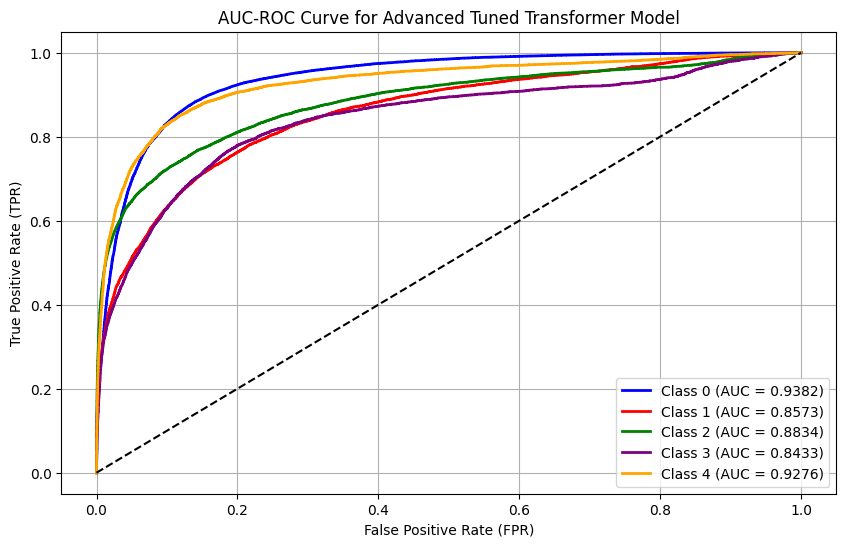

```python
import matplotlib.pyplot as plt
from sklearn.metrics import roc_curve, auc

# Set up the plot
plt.figure(figsize=(10, 6))

# Define colors for each class
colors = ['blue', 'red', 'green', 'purple', 'orange']
class_labels = ["Class 0", "Class 1", "Class 2", "Class 3", "Class 4"]

# Plot ROC curve for each class
for i, color in enumerate(colors):
    binary_labels = (all_labels == i).astype(int)  # Convert to binary for AUC calculation
    fpr, tpr, _ = roc_curve(binary_labels, all_probs[:, i])  # Compute FPR, TPR
    roc_auc = auc(fpr, tpr)  # Compute AUC
    plt.plot(fpr, tpr, color=color, lw=2, label=f'{class_labels[i]} (AUC = {roc_auc:.4f})')

# Plot diagonal (random classifier)
plt.plot([0, 1], [0, 1], color='black', linestyle='--', lw=1.5)

# Labels and title
plt.xlabel("False Positive Rate (FPR)")
plt.ylabel("True Positive Rate (TPR)")
plt.title("AUC-ROC Curve for Advanced Tuned Transformer Model")
plt.legend(loc="lower right")
plt.grid(True)

# Show the plot
plt.show()
```

model comparison

| **Metric** | **Initial Model** | **Tuned Model 1** | **Tuned Model 2** | **Best Model** |
| --- | --- | --- | --- | --- |
| **Test Accuracy** | **73.93%** | **70.98%** | **73.58%** | **Initial** |
| **Macro AUC** | **0.9115** | **0.9060** | **0.8900** | **Initial** |
| **Weighted AUC** | **0.9239** | **0.9189** | **0.9091** | **Initial** |
| **F1 Score (Class 0)(positive)** | **0.88** | **0.85** | **0.87** | **Initial** |
| **F1 Score (Class 1)** | **0.58** | **0.55** | **0.57** | **Initial** |
| **F1 Score (Class 2)** | **0.69** | **0.69** | **0.68** | **Tuned 1** |
| **F1 Score (Class 3)** | **0.46** | **0.43** | **0.44** | **Initial** |
| **F1 Score (Class 4)(Negative)** | **0.63** | **0.64** | **0.62** | **Tuned 1** |

```python
!jupyter nbconvert --to html Transformer.ipynb
```

```
[NbConvertApp] Converting notebook Transformer.ipynb to html
[NbConvertApp] WARNING | Alternative text is missing on 3 image(s).
[NbConvertApp] Writing 760034 bytes to Transformer.html
```